# R : Exploring Penalized Models for Handling High-Dimensional Survival Data

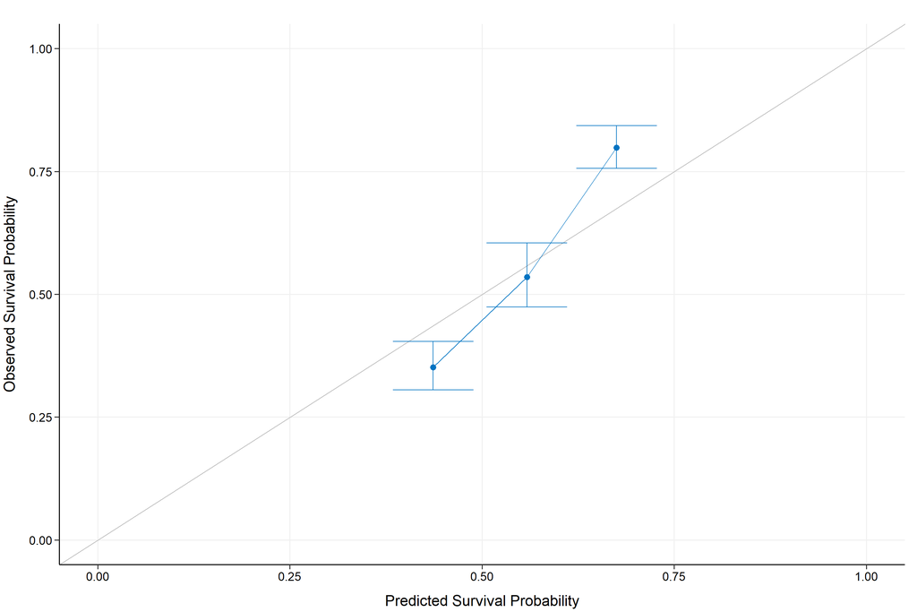

```r
plot(ENET_Train_CoxPH_Model_InternalCalibration)
```

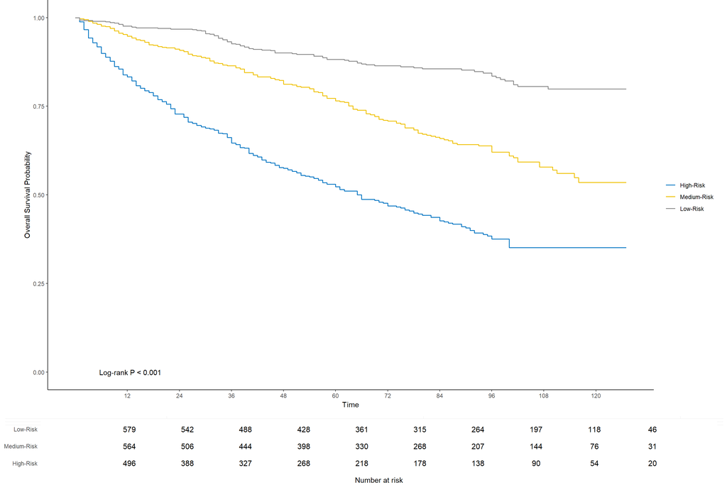

```r
##################################
# Estimating survival curves
# of the ENET model
# for the risk groups
# using the train data
##################################
ENET_Train_CoxPH_Model_KMPlot <- kmplot( ENET_Train_CoxPH_Model_InternalCalibration,
                                          group.name = c("High-Risk", "Medium-Risk", "Low-Risk"),
                                          time.at = 1:10 * 12)
```

```r
##################################
# Conducting an external calibration
# of the ENET model
# using the test data
# for Year 5
##################################
ENET_Train_CoxPH_Model_ExternalCalibration <- calibrate_external(ENET_Train_CoxPH_Fit,
                                                       ENET_Train_Predictors,
                                                       ENET_Train_Time,
                                                       ENET_Train_Status,
                                                       ENET_Test_Predictors,
                                                       ENET_Test_Time,
                                                       ENET_Test_Status,
                                                       pred.at = 60,
                                                       ngroup = 3)

print(ENET_Train_CoxPH_Model_ExternalCalibration)
```

```
## High-Dimensional Cox Model External Calibration Object
## Model type: enet
## Calibration time point: 60
## Number of groups formed for calibration: 3
```

```r
summary(ENET_Train_CoxPH_Model_ExternalCalibration)
```

```
##   External Calibration Summary Table
##   Predicted  Observed Lower 95% Upper 95%
## 1 0.6333423 0.5449845 0.4657763 0.6376625
## 2 0.7270443 0.6847920 0.6092030 0.7697599
## 3 0.8048570 0.8889017 0.8372582 0.9437308
```

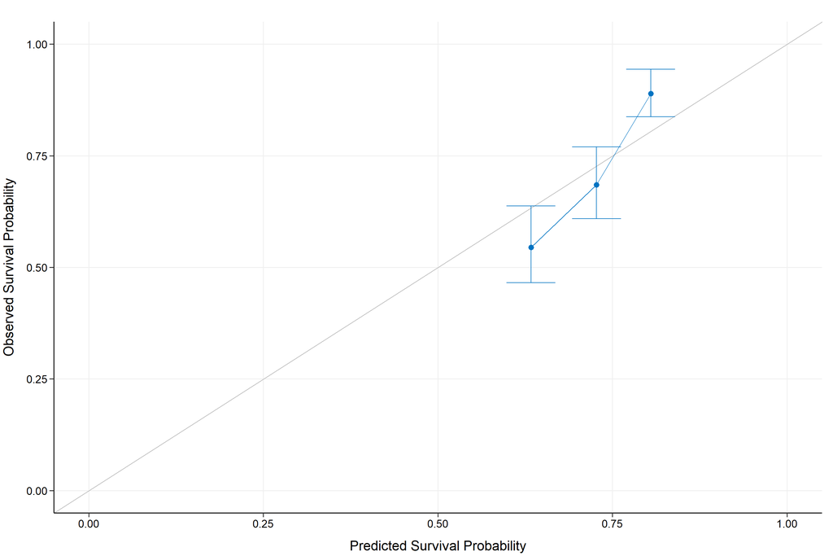

```r
plot(ENET_Train_CoxPH_Model_ExternalCalibration)
```

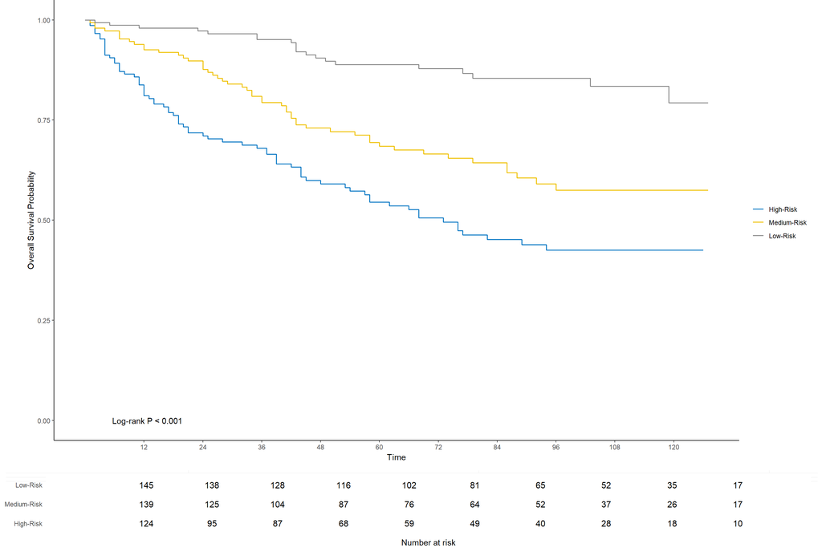

```r
##################################
# Estimating survival curves
# of the ENET model
# for the risk groups
# using the test data
##################################
ENET_Test_CoxPH_Model_KMPlot <- kmplot( ENET_Train_CoxPH_Model_ExternalCalibration,
                                          group.name = c("High-Risk", "Medium-Risk", "Low-Risk"),
                                          time.at = 1:10 * 12)
```

```r
##################################
# Conducting an external calibration
# of the ENET model
# using the test data
# for Year 10
##################################
ENET_Train_CoxPH_Model_ExternalCalibration <- calibrate_external(ENET_Train_CoxPH_Fit,
                                                       ENET_Train_Predictors,
                                                       ENET_Train_Time,
                                                       ENET_Train_Status,
                                                       ENET_Test_Predictors,
                                                       ENET_Test_Time,
                                                       ENET_Test_Status,
                                                       pred.at = 120,
                                                       ngroup = 3)

print(ENET_Train_CoxPH_Model_ExternalCalibration)
```

```
## High-Dimensional Cox Model External Calibration Object
## Model type: enet
## Calibration time point: 120
## Number of groups formed for calibration: 3
```

```r
summary(ENET_Train_CoxPH_Model_ExternalCalibration)
```

```
##   External Calibration Summary Table
##   Predicted  Observed Lower 95% Upper 95%
## 1 0.4309757 0.4249822 0.3421227 0.5279097
## 2 0.5557502 0.5749567 0.4873554 0.6783041
## 3 0.6702783 0.7927570 0.6936271 0.9060539
```

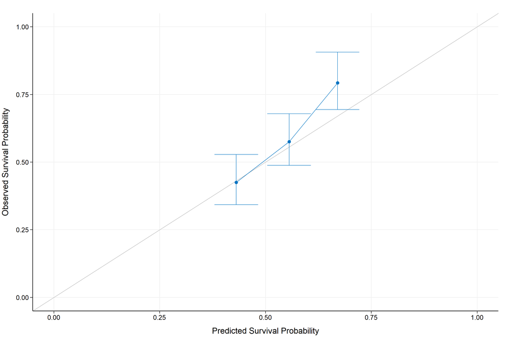

```r
plot(ENET_Train_CoxPH_Model_ExternalCalibration)
```

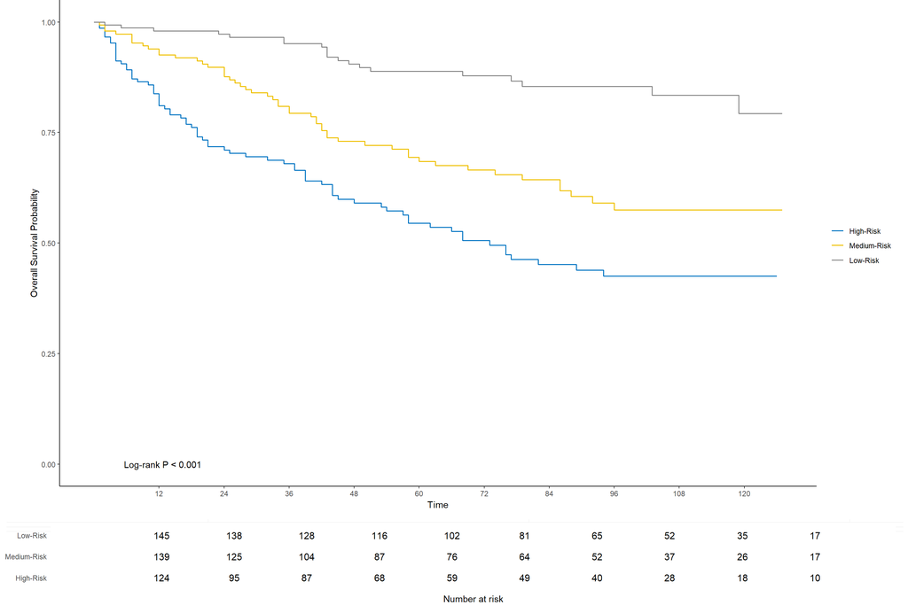

```r
##################################
# Estimating survival curves
# of the ENET model
# for the risk groups
# using the test data
##################################
ENET_Test_CoxPH_Model_KMPlot <- kmplot( ENET_Train_CoxPH_Model_ExternalCalibration,
                                          group.name = c("High-Risk", "Medium-Risk", "Low-Risk"),
                                          time.at = 1:10 * 12)
```

# **2. References**

**[Book]** [Clinical Prediction Models](http://clinicalpredictionmodels.org/) by Ewout Steyerberg  
**[Book]** [Survival Analysis: A Self-Learning Text](https://link.springer.com/book/10.1007/978-1-4419-6646-9/) by David Kleinbaum and Mitchel Klein  
**[Book]** [Applied Survival Analysis Using R](https://link.springer.com/book/10.1007/978-3-319-31245-3/) by Dirk Moore  
**[Book]** [Regression Modeling Strategies](https://link.springer.com/book/10.1007/978-3-319-19425-7/) by Frank Harrell  
**[Book]** [R for Health Data Science](https://argoshare.is.ed.ac.uk/healthyr_book/) by Ewen Harrison and Riinu Pius  
**[Book]** [Supervised Machine Learning](https://bookdown.org/mpfoley1973/supervised-ml/) by Michael Foley  
**[Book]** [Data Science for Biological, Medical and Health Research](https://thomaselove.github.io/432-notes/index.html) by Thomas Love  
**[R Package]** [survival](https://cran.microsoft.com/snapshot/2022-04-01/web/packages/survival/index.html/) by Terry Therneau  
**[R Package]** [survminer](https://cran.r-project.org/web/packages/survminer/index.html/) by Alboukadel Kassambara  
**[R Package]** [mice](https://www.gerkovink.com/miceVignettes/) by Gerko Vink and Stef van Buuren  
**[R Package]** [foreign](https://cran.r-project.org/web/packages/foreign/index.html/) by R Core Team  
**[R Package]** [rms](https://cran.r-project.org/web/packages/rms/index.html/) by Frank Harrell  
**[R Package]** [Hmisc](https://cran.r-project.org/web/packages/Hmisc//) by Frank Harrell and Charles Dupont  
**[R Package]** [VIM](https://cran.r-project.org/web/packages/VIM/index.html/) by Matthias Templ  
**[R Package]** [gridExtra](https://cran.microsoft.com/snapshot/2017-08-01/web/packages/gridExtra/index.html/) by Baptiste Auguie  
**[R Package]** [finalfit](https://cran.r-project.org/web/packages/finalfit/index.html/) by Ewen Harrison  
**[R Package]** [knitr](https://cran.r-project.org/web/packages/knitr/index.html/) by Yihui Xie  
**[R Package]** [dplyr](https://cran.r-project.org/web/packages/dplyr/index.html/) by Hadley Wickham  
**[R Package]** [gtsummary](https://cran.r-project.org/web/packages/gtsummary/index.html/) by Daniel Sjoberg  
**[R Package]** [tidyr](https://cran.r-project.org/web/packages/tidyr/index.html/) by Hadley Wickham  
**[R Package]** [purrr](https://cran.r-project.org/web/packages/purrr//) by Lionel Henry  
**[R Package]** [moments](https://cran.r-project.org/web/packages/moments/index.html) by Lukasz Komsta and Frederick Novomestky  
**[R Package]** [skimr](https://cran.r-project.org/web/packages/skimr/skimr.pdf) by Elin Waring  
**[R Package]** [caret](https://topepo.github.io/caret/index.html) by Max Kuhn  
**[R Package]** [corrplot](https://cran.r-project.org/web/packages/corrplot/corrplot.pdf) by Taiyun Wei  
**[R Package]** [SurvMetrics](https://cran.r-project.org/web/packages/SurvMetrics/SurvMetrics.pdf) by Hanpu Zhou  
**[R Package]** [randomForestSRC](https://cran.r-project.org/web/packages/randomForestSRC/randomForestSRC.pdf) by Hemant Ishwaran and Udaya Kogalur  
**[R Package]** [pec](https://cran.r-project.org/web/packages/pec/pec.pdf) by Thomas Gerds  
**[R Package]** [hdnom](https://cran.r-project.org/web/packages/hdnom/hdnom.pdf) by Nan Xiao  
**[R Package]** [ncvreg](https://cran.r-project.org/web/packages/ncvreg/ncvreg.pdf) by Patrick Breheny  
**[Article]** [An Introduction to hdnom](https://cran.r-project.org/web/packages/hdnom/vignettes/hdnom.html) by Nan Xiao  
**[Article]** [Penalized Cox Models](https://scikit-survival.readthedocs.io/en/stable/user_guide/coxnet.html) by Scikit Survival Team  
**[Article]** [Regularized Cox Regression](https://glmnet.stanford.edu/articles/Coxnet.html) by Kenneth Tay, Noah Simon, Jerome Friedman, Trevor Hastie, Rob Tibshirani and Balasubramanian Narasimhan  
**[Article]** [An Introduction to hdnom](https://cran.r-project.org/web/packages/hdnom/vignettes/hdnom.html) by Nan Xiao  
**[Article]** [An Introduction to hdnom](https://cran.r-project.org/web/packages/hdnom/vignettes/hdnom.html) by Nan Xiao  
**[Article]** [An Introduction to hdnom](https://cran.r-project.org/web/packages/hdnom/vignettes/hdnom.html) by Nan Xiao  
**[Article]** [Predictive Evaluation Metrics in Survival Analysis](https://cran.r-project.org/web/packages/SurvMetrics/vignettes/SurvMetrics-vignette.html) by Zhou Hanpu  
**[Article]** [Survival Analysis](https://sphweb.bumc.bu.edu/otlt/MPH-Modules/BS/BS704_Survival/index.html) by Lisa Sullivan  
**[Article]** [Survival Analysis in R](https://www.emilyzabor.com/tutorials/survival_analysis_in_r_tutorial.html) by Emily Zabor  
**[Article]** [Assessment of Discrimination in Survival Analysis](https://rstudio-pubs-static.s3.amazonaws.com/3506_36a9509e9d544386bd3e69de30bca608.html) by R-Studio Team  
**[Article]** [Cox Proportional-Hazards Regression](https://www.medcalc.org/manual/cox-regression.php) by MedCalc Team  
**[Article]** [Cox Proportional-Hazards Model](https://rstudio-pubs-static.s3.amazonaws.com/3506_36a9509e9d544386bd3e69de30bca608.html) by R Studio Team  
**[Article]** [Exploring Time To Event / Survival Data](https://thomaselove.github.io/432-notes/exploring-time-to-event-survival-data.html) by Thomas Love  
**[Article]** [Survival Analysis](http://www.sthda.com/english/wiki/survival-analysis) by Alboukadel Kassambara  
**[Article]** [Survival Analysis with R](https://rviews.rstudio.com/2017/09/25/survival-analysis-with-r/) by Joseph Rickert  
**[Article]** [Cox Model Assumptions](http://www.sthda.com/english/wiki/cox-model-assumptions#testing-non-linearity) by Alboukadel Kassambara  
**[Article]** [Understanding Predictions in Survival Analysis](https://scikit-survival.readthedocs.io/en/stable/user_guide/understanding_predictions.html) by Scikit Team  
**[Article]** [Regularization in R Tutorial: Ridge, Lasso and Elastic Net](https://www.datacamp.com/tutorial/tutorial-ridge-lasso-elastic-net) by Datacamp Team  
**[Article]** [Penalized Regression Essentials: Ridge, Lasso & Elastic Net](http://sthda.com/english/articles/37-model-selection-essentials-in-r/153-penalized-regression-essentials-ridge-lasso-elastic-net) by STHDA Team  
**[Article]** [Lasso vs Ridge vs Elastic Net | ML](https://www.geeksforgeeks.org/lasso-vs-ridge-vs-elastic-net-ml/) by Geeks for Geeks Team  
**[Article]** [Lasso Regression Explained, Step by Step](https://machinelearningcompass.com/machine_learning_models/lasso_regression/) by Boris Giba  
**[Article]** [How to Develop LASSO Regression Models in Python](https://machinelearningmastery.com/lasso-regression-with-python/) by Jason Brownlee  
**[Article]** [Introduction to Lasso Regression](https://www.statology.org/lasso-regression/) by Statology Team  
**[Article]** [Elastic Net Regression Explained, Step by Step](https://machinelearningcompass.com/machine_learning_models/elastic_net_regression/) by Boris Giba  
**[Article]** [How to Develop Elastic Net Regression Models in Python](https://machinelearningmastery.com/elastic-net-regression-in-python/) by Jason Brownlee  
**[Article]** [Adaptive Lasso: What It Is and How to Implement in R](https://ricardocarvalho.ca/post/lasso/) by Ricardo Carvalho  
**[Article]** [L1 Penalization: The Lasso and Adaptive Lasso](http://www.personal.psu.edu/lxx6/Lasso.pdf) by Justin Petrovich  
**[Article]** [Adaptive Lasso, MCP, and SCAD](https://myweb.uiowa.edu/pbreheny/7600/s16/notes/2-29.pdf) by Patrick Breheny  
**[Article]** [The Smoothly Clipped Absolute Deviation (SCAD) penalty](https://andrewcharlesjones.github.io/journal/scad.html) by Andrew Jones  
**[Article]** [Fused Lasso](https://myweb.uiowa.edu/pbreheny/7240/s19/notes/5-01.pdf) by Patrick Breheny  
**[Publication]** [Survival Analysis Part I: Basic Concepts and First Analyses](https://www.ncbi.nlm.nih.gov/pmc/articles/PMC2394262/) by Taane Clark (British Journal of Cancer)  
**[Publication]** [Survival Analysis Part II: Multivariate Data Analysis – An Introduction to Concepts and Methods](https://www.ncbi.nlm.nih.gov/pmc/articles/PMC2394368/) by Mike Bradburn (British Journal of Cancer)  
**[Publication]** [Survival Analysis Part III: Multivariate Data Analysis – Choosing a Model and Assessing its Adequacy and Fit](https://www.ncbi.nlm.nih.gov/pmc/articles/PMC2376927/) by Mike Bradburn (British Journal of Cancer)  
**[Publication]** [Survival Analysis Part IV: Further Concepts and Methods in Survival Analysis](https://www.ncbi.nlm.nih.gov/pmc/articles/PMC2394469/) by Taane Clark (British Journal of Cancer)  
**[Publication]** [Regression Models and Life-Tables](https://rss.onlinelibrary.wiley.com/doi/abs/10.1111/j.2517-6161.1972.tb00899.x) by David Cox (Royal Statistical Society)  
**[Publication]** [Regression Shrinkage and Selection Via the Lasso](https://rss.onlinelibrary.wiley.com/doi/abs/10.1111/j.2517-6161.1996.tb02080.x) by Rob Tibshirani (Journal of the Royal Statistical Society)  
**[Publication]** [The Adaptive Lasso and Its Oracle Properties](https://www.tandfonline.com/doi/pdf/10.1198/016214506000000735) by Hui Zou (Journal of the American Statistical Association)  
**[Publication]** [Regularization and Variable Selection via the Elastic Net](https://rss.onlinelibrary.wiley.com/doi/10.1111/j.1467-9868.2005.00503.x) by Hui Zou and Trevor Hastie (Journal of the Royal Statistical Society)  
**[Publication]** [On The Adaptive Elastic-Net With a Diverging Number of Parameters](https://pubmed.ncbi.nlm.nih.gov/20445770/) by Hui Zou and Hao Helen Zhang (Annals of Statistics)  
**[Publication]** [Adaptive Elastic Net Method for Cox Model](https://arxiv.org/abs/1507.06371) by Chunhong Li, Xinxing Wei and Hongshuai Dai (arXiv e-prints)  
**[Publication]** [Coordinate Descent Algorithms for Non-Convex Penalized Regression with Applications to Biological Feature Selection](https://pubmed.ncbi.nlm.nih.gov/22081779/) by Patrick Breheny and Jian Huang (The Annals of Applied Statistics)  
**[Publication]** [Regularization Paths for Cox’s Proportional Hazards Model via Coordinate Descent](https://pubmed.ncbi.nlm.nih.gov/27065756/) by Noah Simon, Jerome Friedman, Trevor Hastie and Rob Tibshirani (Journal of Statistical Software)  
**[Publication]** [Nearly Unbiased Variable Selection Under Minimax Concave Penalty](https://www.jstor.org/stable/25662264) by Cunhui Zhang (The Annals of Statistics)  
**[Publication]** [Sparsity and Smoothness via the Fused Lasso](https://www.jstor.org/stable/3647602) by Robert Tibshirani, Michael Saunders, Saharon Rosset, Ji Zhu and Keith Knight (Journal of the Royal Statistical Society)  
**[Tutorial]** [Survival Analysis / Time-To-Event Analysis in R](https://campus.datacamp.com/courses/survival-analysis-in-r/what-is-survival-analysis?ex=1) by Heidi Seibold (Datacamp)